# Analyse de la Durabilité dans le Secteur du Thé

KOUASSI KONAN LEGER

2025-05-22

# Introduction

Ce document présente une analyse approfondie de la durabilité dans le secteur du thé. L’objectif est d’identifier et d’analyser les tendances en matière de labels et certifications durables, ainsi que leur impact sur le marché.

## Objectifs de l’analyse

1. Comprendre l’évolution des labels durables dans le temps
2. Analyser la relation entre les labels et les prix
3. Identifier les marchés les plus engagés en matière de durabilité
4. Examiner les différences entre les sous-catégories de thé

# Méthodologie

## Données utilisées

L’analyse est basée sur la base de données GNPD (Global New Products Database) pour le secteur du thé. Les données incluent : - Les claims de positionnement des produits - Les prix - Les marchés - Les sous-catégories - Les dates de publication

## Dictionnaire de labels durables

Le dictionnaire de labels durables est structuré en 5 catégories principales :

1. **Certifications officielles**
   - Labels bio/organiques
   - Commerce équitable
   - Autres certifications reconnues
2. **Environnement et biodiversité**
   - Termes liés à la durabilité environnementale
   - Protection de la biodiversité
   - Gestion des ressources
3. **Social et éthique**
   - Aspects sociaux
   - Conditions de travail
   - Impact communautaire
4. **Agriculture durable**
   - Pratiques agricoles durables
   - Gestion des sols et de l’eau
   - Protection des écosystèmes
5. **Emballage et transport**
   - Solutions d’emballage durables
   - Circuits courts
   - Réduction des déchets

# Résultats

## 1. Évolution temporelle des labels

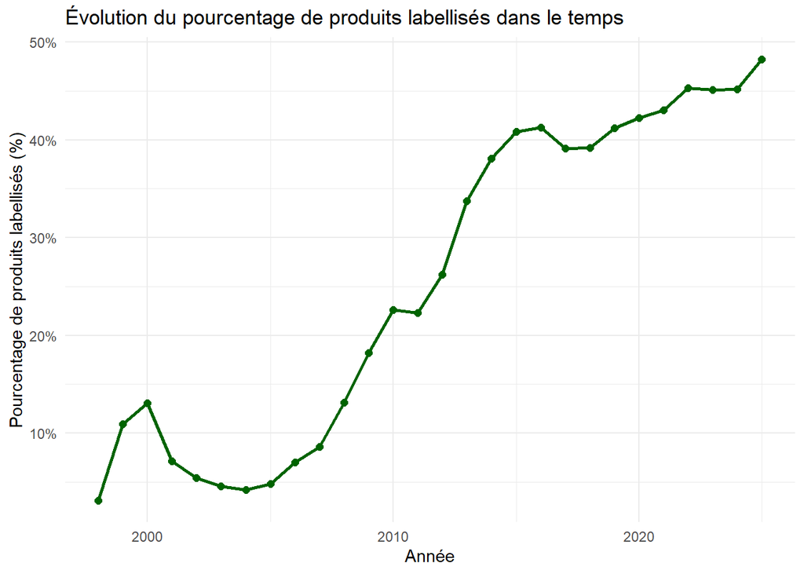

Cette section montre l’évolution du pourcentage de produits labellisés au fil du temps, permettant d’identifier les tendances et les changements dans l’adoption des pratiques durables.

## 2. Analyse des prix

[figure not shown]

## 3. Analyse par marché

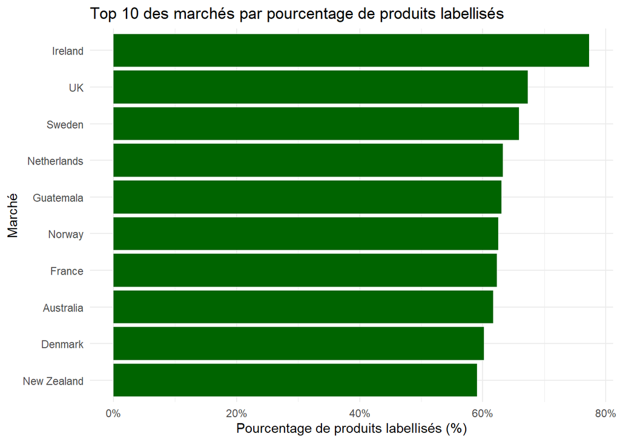

Cette section identifie les marchés les plus engagés en matière de durabilité, en se concentrant sur les marchés avec un nombre significatif de produits.

## 4. Analyse par sous-catégorie

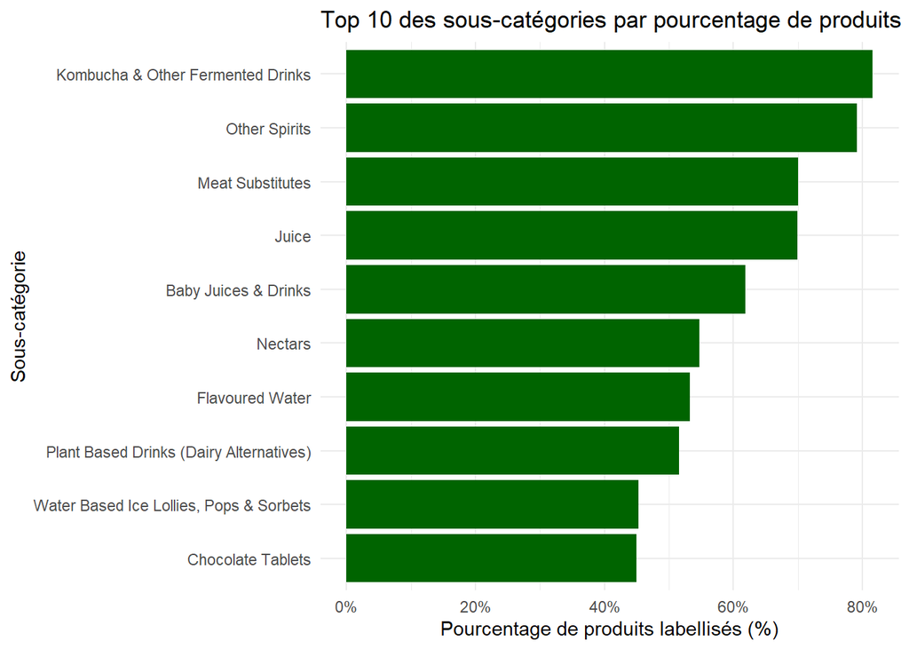

# Conclusions

## Recommandations

1. **Pour les producteurs** :
   - Développer des stratégies de labellisation adaptées à chaque marché
   - Communiquer la valeur ajoutée des labels durables
   - Investir dans des certifications reconnues
2. **Pour les distributeurs** :
   - Mettre en avant les produits labellisés
   - Éduquer les consommateurs sur la valeur des labels
   - Développer des gammes de produits durables
3. **Pour les consommateurs** :
   - Privilégier les produits labellisés
   - Comprendre la signification des différents labels
   - Être prêt à payer une prime pour des produits durables

# Annexes

## Code source

Le code source complet de l’analyse est disponible dans le fichier `analyse_durabilite.R`.

## Références

- Global New Products Database (GNPD)
- Standards et certifications durables
- Études sur la durabilité dans le secteur du thé